# Music Genre Prediction and Multiclass Classification

By Chibueze Nwade & Joshua Ng

# Brief

The goal of this tutorial is to compare Machine Learning models to predict the genre of popular songs and to determine how each model fairs in handling a Multiclass Classification problem with significant class imbalances. The models used in this tutorial are the Logistic Regression model, K-Nearest Neighbors Classifier, Decision Tree Classifier, and Random Forest Classifier.

# Introduction

It is very common to listen to a song and wonder who is the artist that made the song or what the name of the song is. This has ultimately resulted in various forms of applications being created such as Shazam, the song identification feature of Google Assistant, and many others. Have you, however, ever wondered what a song’s genre is from listening to it.

If you have, then you are in luck because that is the purpose of this tutorial. In this tutorial, we are going to demonstrate the process taken to create a Machine Learning model (or better yet, a variety of Machine Learning models) that predicts the genre of a song based on its features such as the artist that made the song, the energy in the song, the tempo of the song (labeled as beats per minute), and much more. To accomplish this, we are going to use the [Spotify – All Time Top 2000s Mega Dataset](https://www.kaggle.com/datasets/iamsumat/spotify-top-2000s-mega-dataset) that we found on Kaggle, that provides information on the most popular songs from the year 1956 to the year 2019.

In addition to showcasing the process of creating Machine Learning models to make predictions on values such as genres, the focus of this tutorial is to also present ideas on how to handle a Multiclass Classification problem, especially when there are significant imbalances in the classes. We hope this tutorial would shed some insight as to how the Machine Learning process works and would also provide more experienced Machine Learning enthusiasts with a different perspective on how to handle Multiclass Classification problems.

# Libraries and Imports

[figure not shown]

```python
# Importing Visualization Tools
import pandas as pd
import numpy as np
import seaborn as sns
import matplotlib.pyplot as plt

# For training and feature engineering
from sklearn.model_selection import train_test_split
from sklearn.model_selection import cross_val_score
from sklearn.utils import class_weight
from sklearn.preprocessing import StandardScaler
from imblearn.over_sampling import SMOTE
from imblearn.pipeline import make_pipeline

# Models to be used, all from sklearn
from sklearn.ensemble import RandomForestClassifier
from sklearn.linear_model import LogisticRegression
from sklearn.neighbors import KNeighborsClassifier
from sklearn.tree import DecisionTreeClassifier

# Metrics
from sklearn.metrics import accuracy_score, f1_score, confusion_matrix, recall_score, precision_score, classification_report

# Hyper Parameter Tuning
from sklearn.model_selection import GridSearchCV
from xgboost import XGBRegressor

# Hypothesis Testing
from scipy.stats import chi2_contingency

# set sns settings
sns.set(font_scale=0.9)
sns.set(rc={'figure.figsize':(21,12)})
plt.style.use('fivethirtyeight')
plt.xticks(rotation=45)

#other
import warnings
```

```python
import os
os.listdir()
```

```
['.config', 'sample_data']
```

# Importing and Loading the Data

To import the data, we chose to import it from the GitHub repository of the final project so as to bypass some of the limitations of using Google Colab to host our notebook.

```python
url = 'https://raw.githubusercontent.com/cnwade08/CMSC320-Final-Project/main/Spotify-2000.csv'
df = pd.read_csv(url)
df.head(5)
```

|  | Index | Title | Artist | Top Genre | Year | Beats Per Minute (BPM) | Energy | Danceability | Loudness (dB) | Liveness | Valence | Length (Duration) | Acousticness | Speechiness | Popularity |
| --- | --- | --- | --- | --- | --- | --- | --- | --- | --- | --- | --- | --- | --- | --- | --- |
| 0 | 1 | Sunrise | Norah Jones | adult standards | 2004 | 157 | 30 | 53 | -14 | 11 | 68 | 201 | 94 | 3 | 71 |
| 1 | 2 | Black Night | Deep Purple | album rock | 2000 | 135 | 79 | 50 | -11 | 17 | 81 | 207 | 17 | 7 | 39 |
| 2 | 3 | Clint Eastwood | Gorillaz | alternative hip hop | 2001 | 168 | 69 | 66 | -9 | 7 | 52 | 341 | 2 | 17 | 69 |
| 3 | 4 | The Pretender | Foo Fighters | alternative metal | 2007 | 173 | 96 | 43 | -4 | 3 | 37 | 269 | 0 | 4 | 76 |
| 4 | 5 | Waitin' On A Sunny Day | Bruce Springsteen | classic rock | 2002 | 106 | 82 | 58 | -5 | 10 | 87 | 256 | 1 | 3 | 59 |

```python
df.columns
```

```
Index(['Index', 'Title', 'Artist', 'Top Genre', 'Year',
       'Beats Per Minute (BPM)', 'Energy', 'Danceability', 'Loudness (dB)',
       'Liveness', 'Valence', 'Length (Duration)', 'Acousticness',
       'Speechiness', 'Popularity'],
      dtype='object')
```

## Check for Null Values

The dataset looks pretty clean with no null values, so let's proceed.

```python
df.isnull().sum()
```

```
Index                     0
Title                     0
Artist                    0
Top Genre                 0
Year                      0
Beats Per Minute (BPM)    0
Energy                    0
Danceability              0
Loudness (dB)             0
Liveness                  0
Valence                   0
Length (Duration)         0
Acousticness              0
Speechiness               0
Popularity                0
dtype: int64
```

## Check for Duplicates

To prevent having duplicates that could potentially affect the effective of the models that we are using, we chose to check for duplicates and to remove them if any were present.

```python
df.duplicated().sum()
```

```
0
```

# Feature Selection (Visualizations for each Feature against the Genre Target)

```python
#displaying the features
df = df.sort_values("Top Genre")
features = list(df.columns[4:])
features
```

```
['Year',
 'Beats Per Minute (BPM)',
 'Energy',
 'Danceability',
 'Loudness (dB)',
 'Liveness',
 'Valence',
 'Length (Duration)',
 'Acousticness',
 'Speechiness',
 'Popularity']
```

## Years

More varied genres as the years went by and Album Rock which had it's hey day in the 70s died down in popularity.

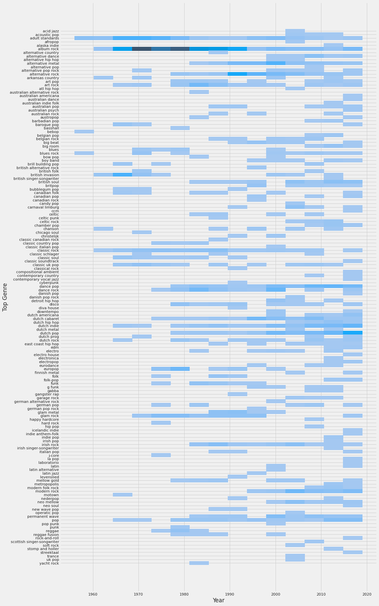

```python
plt.figure(figsize=(15,30))
ax = sns.histplot(data= df, x= features[0], y="Top Genre")

plt.show()
```

## BPM

BPM stands for Beats Per Minute. It is a measure of how fast or slow paced the song is. Whether the data is sparse or dense, most genres have a good spread of BPM. Some genres like gangster rap will occupy the lower half of the spectrum, but those are outliers.

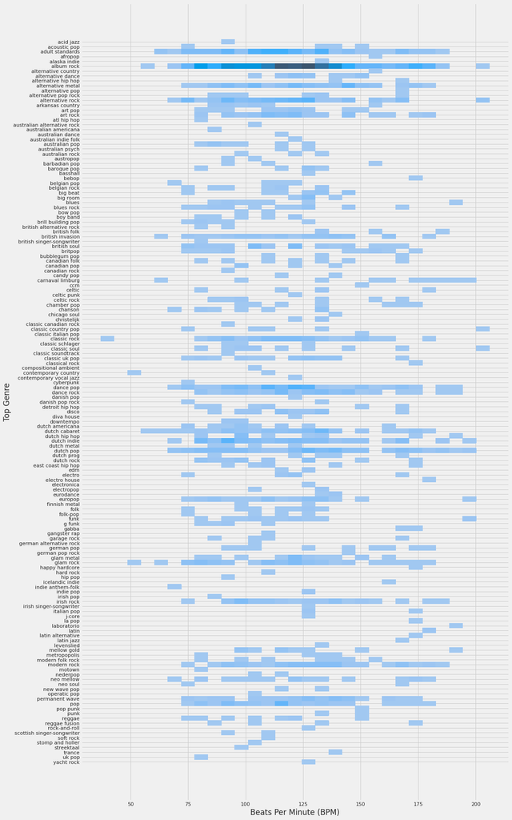

```python
plt.figure(figsize=(15,30))
ax = sns.histplot(data= df, x= features[1], y="Top Genre")

plt.show()
```

## Energy

Energy is closely related to BPM. It is Spotify's way of quantifying a subjective perception of a song's intensity and activity.

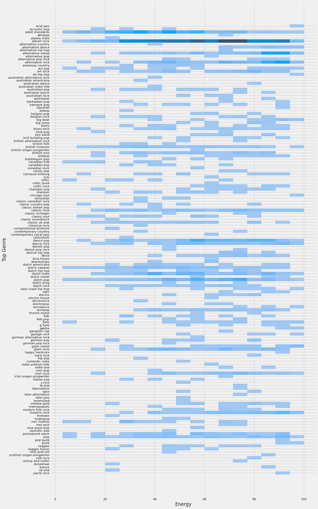

```python
plt.figure(figsize=(15,30))
ax = sns.histplot(data= df, x= features[2], y="Top Genre")

plt.show()
```

For example, metal which has a lot of screaming, could have higher Energy levels.

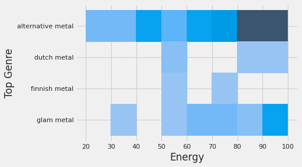

```python
plt.figure(figsize=(6,4))
ax = sns.histplot(data= df.loc[df["Top Genre"].str.contains("metal")], x= features[2], y="Top Genre")

plt.show()
```

## Danceability

A measure of how suitable a song is for dancing to. There's pretty wide spread for some genres but for other genres, its quite a small range.

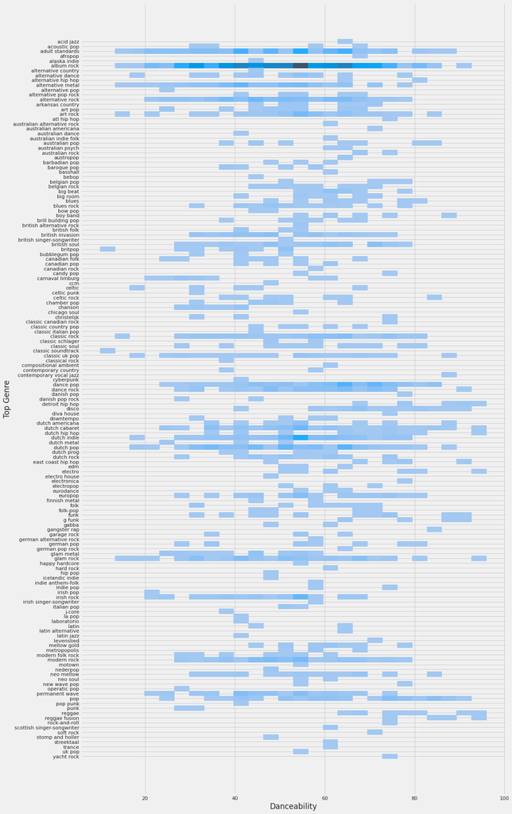

```python
plt.figure(figsize=(15,30))
ax = sns.histplot(data= df, x= features[3], y="Top Genre")

plt.show()
```

## Loudness

Most songs are within a certain range from -20 to -5 dB, probably for safety concerns.

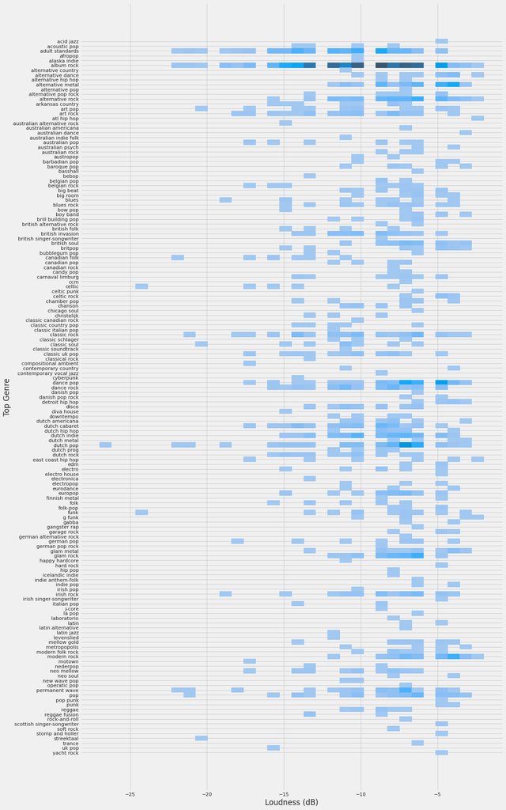

```python
plt.figure(figsize=(15,30))
ax = sns.histplot(data= df, x= features[4], y="Top Genre")

plt.show()
```

## Liveness

A measure of the likelihood that an audience is in the recording. People can be divided over whether studio versus live versions of songs are better, but in this case most of the top 2000 songs have low Liveness scores. Since they are so similar, it's probably not very useful but would still be included in our analysis.

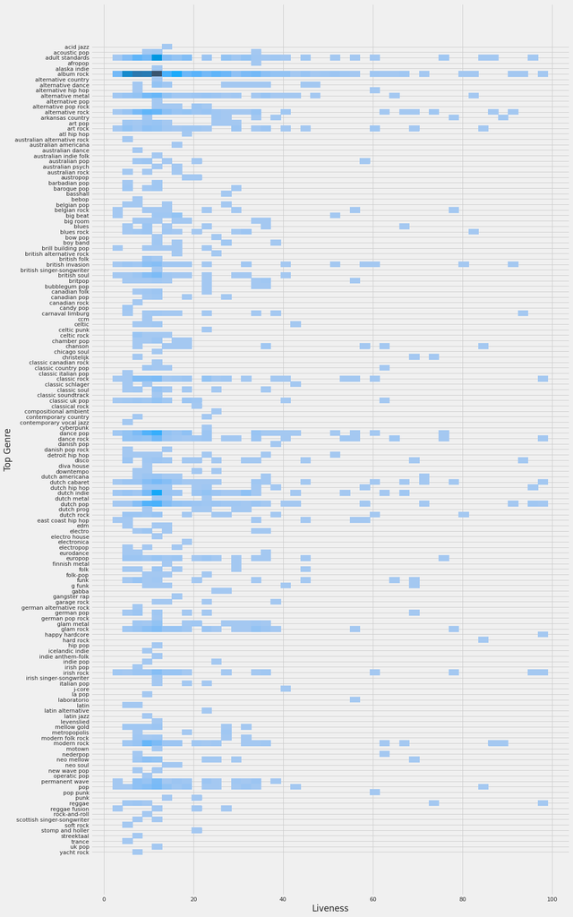

```python
plt.figure(figsize=(15,30))
ax = sns.histplot(data= df, x= features[5], y="Top Genre")

plt.show()
```

## Valence

A measure of how positive a song is. 0 is negative and 100 is positive. Popular songs span the gamut, which makes sense because both positive and negative valences evoke strong emotional responses and experiences.

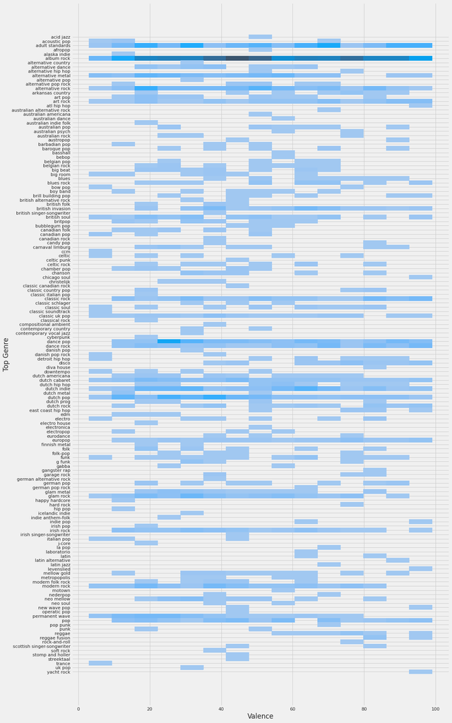

```python
plt.figure(figsize=(15,30))
ax = sns.histplot(data= df, x= features[6], y="Top Genre")

plt.show()
```

## Length

Song lengths vary widely, especially for rock songs which are famous for their never ending virtuosic solos, but also many other genres. Since the length of a song does not offer much information about the song, this feature would not be used.

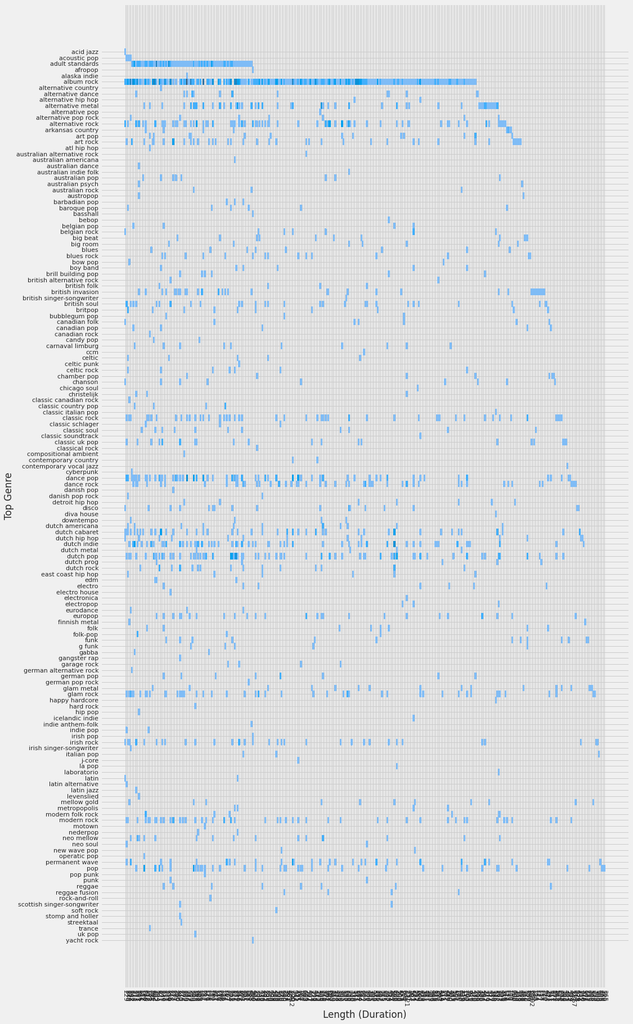

```python
plt.figure(figsize=(15,30))
ax = sns.histplot(data= df, x= features[7], y="Top Genre")
plt.xticks(rotation=-90)
plt.show()
```

## Acousticness

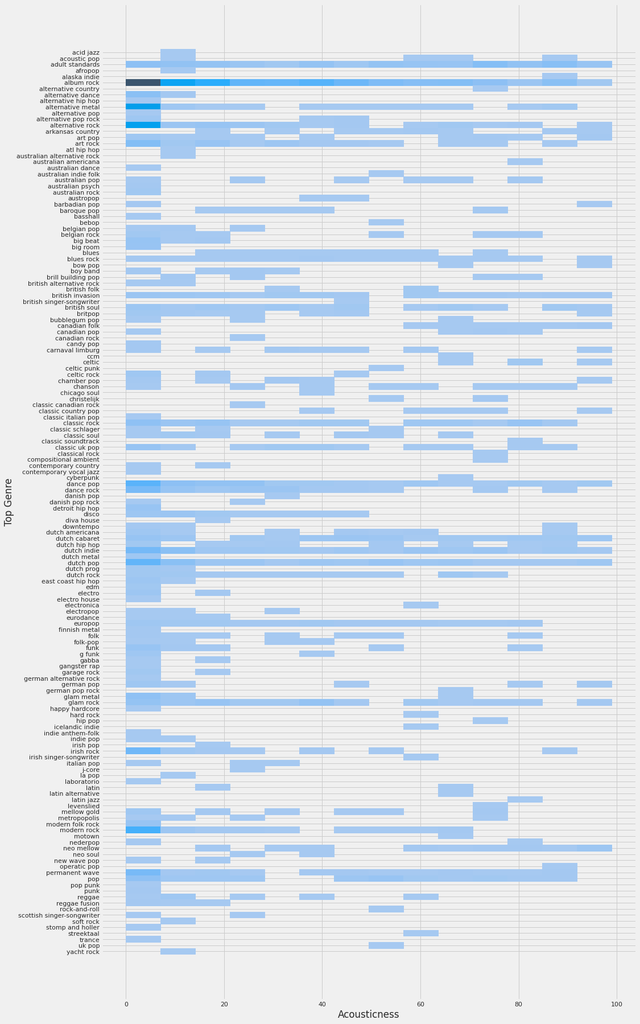

```python
plt.figure(figsize=(15,30))
ax = sns.histplot(data= df, x= features[8], y="Top Genre")

plt.show()
```

## Speechiness

Speechiness is how speech-like a song is, like a book or a poetry. It's interesting to note that most of the popular songs have low speechiness, and the highest value is 55, even though the scale goes up to 100.

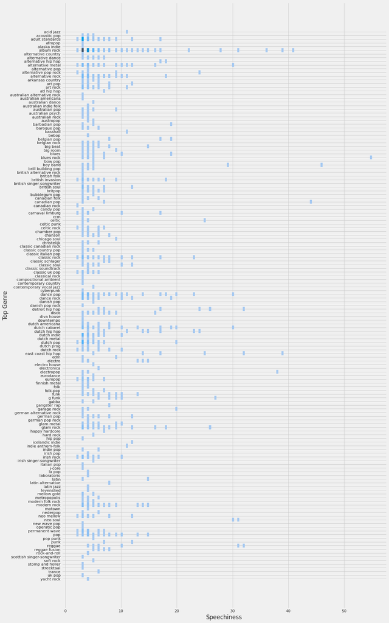

```python
plt.figure(figsize=(15,30))
ax = sns.histplot(data= df, x= features[9], y="Top Genre")

plt.show()
```

```python
df.loc[df["Speechiness"] == df["Speechiness"].max()]
```

|  | Index | Title | Artist | Top Genre | Year | Beats Per Minute (BPM) | Energy | Danceability | Loudness (dB) | Liveness | Valence | Length (Duration) | Acousticness | Speechiness | Popularity |
| --- | --- | --- | --- | --- | --- | --- | --- | --- | --- | --- | --- | --- | --- | --- | --- |
| 864 | 865 | Mercedes Benz | Janis Joplin | blues rock | 1971 | 87 | 11 | 70 | -15 | 7 | 52 | 108 | 94 | 55 | 58 |

## Popularity

A measure of how popular a song is, calculated on the number of plays a track has. Most genres are solidly in the middle, not severely skewed left or right.

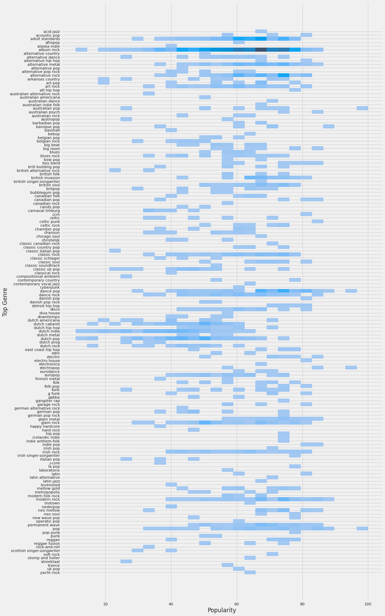

```python
plt.figure(figsize=(15,30))
ax = sns.histplot(data= df, x= features[10], y="Top Genre")

plt.show()
```

Spread and number of outliers might be a good predictor of genre type for features like acousticness, valence, liveness, loudness, bpm

## Heatmap of Correlation of features

The table of correlations can be difficult to visualise numerically, so lets use a heatmap.

```python
df.corr()
```

|  | Index | Year | Beats Per Minute (BPM) | Energy | Danceability | Loudness (dB) | Liveness | Valence | Acousticness | Speechiness | Popularity |
| --- | --- | --- | --- | --- | --- | --- | --- | --- | --- | --- | --- |
| Index | 1.000000 | -0.607910 | -0.048918 | -0.114307 | -0.047156 | -0.260179 | -0.027125 | 0.063304 | 0.057346 | -0.050991 | 0.087442 |
| Year | -0.607910 | 1.000000 | 0.012570 | 0.147235 | 0.077493 | 0.343764 | 0.019017 | -0.166163 | -0.132946 | 0.054097 | -0.158962 |
| Beats Per Minute (BPM) | -0.048918 | 0.012570 | 1.000000 | 0.156644 | -0.140602 | 0.092927 | 0.016256 | 0.059653 | -0.122472 | 0.085598 | -0.003181 |
| Energy | -0.114307 | 0.147235 | 0.156644 | 1.000000 | 0.139616 | 0.735711 | 0.174118 | 0.405175 | -0.665156 | 0.205865 | 0.103393 |
| Danceability | -0.047156 | 0.077493 | -0.140602 | 0.139616 | 1.000000 | 0.044235 | -0.103063 | 0.514564 | -0.135769 | 0.125229 | 0.144344 |
| Loudness (dB) | -0.260179 | 0.343764 | 0.092927 | 0.735711 | 0.044235 | 1.000000 | 0.098257 | 0.147041 | -0.451635 | 0.125090 | 0.165527 |
| Liveness | -0.027125 | 0.019017 | 0.016256 | 0.174118 | -0.103063 | 0.098257 | 1.000000 | 0.050667 | -0.046206 | 0.092594 | -0.111978 |
| Valence | 0.063304 | -0.166163 | 0.059653 | 0.405175 | 0.514564 | 0.147041 | 0.050667 | 1.000000 | -0.239729 | 0.107102 | 0.095911 |
| Acousticness | 0.057346 | -0.132946 | -0.122472 | -0.665156 | -0.135769 | -0.451635 | -0.046206 | -0.239729 | 1.000000 | -0.098256 | -0.087604 |
| Speechiness | -0.050991 | 0.054097 | 0.085598 | 0.205865 | 0.125229 | 0.125090 | 0.092594 | 0.107102 | -0.098256 | 1.000000 | 0.111689 |
| Popularity | 0.087442 | -0.158962 | -0.003181 | 0.103393 | 0.144344 | 0.165527 | -0.111978 | 0.095911 | -0.087604 | 0.111689 | 1.000000 |

Here's a heatmap of the correlation between features. Columns with non numerical data aren't included because they can't be correlated.

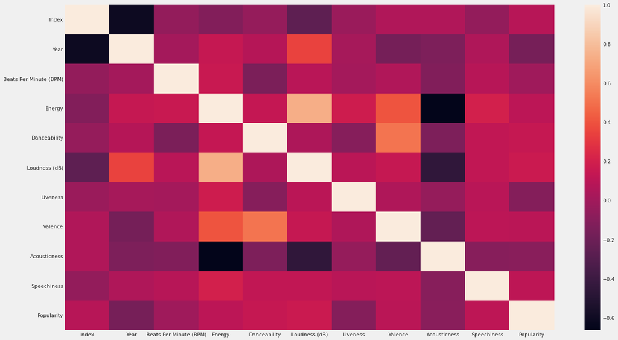

```python
sns.heatmap(df.corr())
```

A lot of the heatmap makes sense:

1. Acousticness has a poor correlation to Energy. While there could be many "Intense" and "Active" that are also produced using acoustic instruments such as Fiddle songs, a lot of those songs aren't popular anymore. Upbeat songs that are also popular would mostly be produced using electronic instruments.
2. Valence has good correlation to Energy and Danceability. If a song "feels positive" there's a good chance there's a groove to dance to and the energy is high enough to dance to.
3. Year has a good correlation to Loudness. Songs get louder as the years go by.
4. Energy and Loudness have good correlation.
5. Acousticness and Loudness have poor correlation. For the most part, unless the song is a loud orchestral piece, it's unlikely for an acoustic piece to be loud. For a song to be loud and still popular, it's likely that lots of audio engineering was involved, making it more likely to utilise electronic instruments.
6. Weirdly, Popularity isn't a good indicator of a song's other features. It's highly likely popularity is affected by other external factors that aren't captured by the dataset, such as marketing, Spotify's own suggestions to it's users, and user demographic.

# A Note on the Target Variable i.e. Top Genre

Looking at the count of the genres, we can that there is a major disparity in the representation of each genre. There are 149 unique genres in the dataset but there are only 10 genres that appear in the dataset more than 50 times, whereas there are up to 89 unique genres that appear in the dataset less than 5 times. Additionally, among the top 10 most appearing genres, there is a huge difference between the genre in first place and the genre in second place. These disparities in the appearance between the genres would result in major imbalances between the genres in the dataset and could ultimately affect the performances of the models that we would use to make our predictions.

```python
genres_count = df['Top Genre'].value_counts()
print('Number of Genres:',len(df['Top Genre'].unique()))
print('Number of genres that appear more than 50 times:', len(genres_count.index[genres_count > 50].tolist()))
print('Number of genres that appear less than 5 times:', len(genres_count.index[genres_count < 5].tolist()))
print('Top 10 genres:\n', genres_count.head(10))
```

```
Number of Genres: 149
Number of genres that appear more than 50 times: 10
Number of genres that appear less than 5 times: 89
Top 10 genres:
 album rock           413
adult standards      123
dutch pop             88
alternative rock      86
dance pop             83
dutch indie           75
alternative metal     70
dance rock            52
dutch cabaret         51
classic rock          51
Name: Top Genre, dtype: int64
```

# Feature Engineering

## Grouping the Genres

To handle the issue of imbalances, we chose to use a variety of methods with the first one being grouping identifiable sub-genres with their much more encompassing genres. An example of such a grouping would be grouping the Dutch Pop sub-genre with other sub-genres of pop to create a new genre that would be called Pop. This operation was done for only the genres of Rock, Pop, Folk, Hip Hop, and Metal as they were the only genres that we were able to easily identify their sub-genres. To do these groupings, we created a simple function that returned one of aforementioned genres if the sub-genre passed in as an argument contained the genre as part of its name. If the sub-genre passed in as an argument did not contain any of the genres as a substring of its name, then its original name was returned. To apply the function to the dataset, we first created a copy of the original data frame that we were previously working with and then used the apply function from pandas to create a new column called ‘New Genres’ from the result of calling the function on the ‘Top Genres’ column. Once this new column was created, we added it to the copy of the data frame that we created.

```python
#print(df['Top Genre'].unique())
def group_genres(genre):
  if genre.find('rock') != -1:
    return 'Rock'
  elif genre.find('pop') != -1:
    return 'Pop'
  elif genre.find('folk') != -1:
    return 'Folk'
  elif genre.find('hip hop') != -1:
    return 'Hip Hop'
  elif genre.find('metal') != -1:
    return 'Metal'
  else:
    return genre

#df for grouped genres
df_copy1 = df.copy()
df_copy1['New Genres'] = df['Top Genre'].apply(group_genres)
print(df_copy1['New Genres'].unique())
print(df_copy1['New Genres'].value_counts())
```

```
['acid jazz' 'Pop' 'adult standards' 'alaska indie' 'Rock'
 'alternative country' 'alternative dance' 'Hip Hop' 'Metal'
 'arkansas country' 'australian americana' 'australian dance' 'Folk'
 'australian psych' 'basshall' 'bebop' 'big beat' 'big room' 'blues'
 'boy band' 'british invasion' 'british singer-songwriter' 'british soul'
 'carnaval limburg' 'ccm' 'celtic' 'celtic punk' 'chanson' 'chicago soul'
 'christelijk' 'classic schlager' 'classic soul' 'classic soundtrack'
 'compositional ambient' 'contemporary country' 'contemporary vocal jazz'
 'cyberpunk' 'disco' 'diva house' 'downtempo' 'dutch americana'
 'dutch cabaret' 'dutch indie' 'dutch prog' 'edm' 'electro'
 'electro house' 'electronica' 'eurodance' 'funk' 'g funk' 'gabba'
 'gangster rap' 'happy hardcore' 'icelandic indie'
 'irish singer-songwriter' 'j-core' 'laboratorio' 'latin'
 'latin alternative' 'latin jazz' 'levenslied' 'mellow gold' 'motown'
 'neo mellow' 'neo soul' 'permanent wave' 'punk' 'reggae' 'reggae fusion'
 'scottish singer-songwriter' 'stomp and holler' 'streektaal' 'trance']
Rock               857
Pop                388
adult standards    123
Metal               93
dutch indie         75
                  ...
cyberpunk            1
diva house           1
electro house        1
electronica          1
trance               1
Name: New Genres, Length: 74, dtype: int64
```

## One Hot Encoding the Artist Column

In addition to creating the ‘New Target’ column, which we eventually used as our target variable, we also added another much-needed feature to help with our model creation and predictions. Since we viewed the Artist name to be a crucial part of a song’s genre, we chose to make the ‘Artist’ feature a usable part for our models by one-hot encoding the column because the name of the artists was nominal data. To achieve this, we used the get_dummies function from Pandas and concatenated the result of the function to a copy of our original dataset and also to the dataset created in the previous step. Afterwards, we deleted the ‘Artist’ column as it was unneeded and proceeded to use the newly created copy of our data frame as our main data frame for the rest of the tutorial.

```python
df.columns
df_copy = df.copy()

#one hot encode the artist names
dummies = pd.get_dummies(df['Artist'], prefix='artist')
df_copy = pd.concat([df_copy, dummies], axis=1)
df_copy = df_copy.drop('Artist', axis = 1)
df_copy.head()
df_copy.columns
df_copy1 = pd.concat([df_copy1, dummies], axis=1)
df_copy1 = df_copy1.drop('Artist', axis = 1)
```

# Initial Predictions with default parameters for each model

## Prediction with Top Genre

The poor scores of each of the models can be chalked up to a number of factors but the main factor that stands out is the imbalance between the genres in the dataset. This is especially apparent in the K-Nearest Neighbor Classifier which does not fare well with unbalanced classes, and the Logistic Regression model which already does not properly handle multiclass classification problems by default and proceeds to perform worse if the classes are imbalanced. These were the main issues that we attempted to address in the next steps and we attempted to do so in a variety of ways.

```python
# creating the train/test split using regular sub genre
y = df_copy['Top Genre']
X = df_copy.drop(['Index', 'Title', 'Top Genre', 'Length (Duration)'], axis=1)
X_train, X_test, y_train, y_test = train_test_split(X, y, train_size = 0.6, random_state = 42)
```

```python
# creating a default knn classifier model
knn_model = KNeighborsClassifier()
knn_model.fit(X_train, y_train)

#making a prediction using the knn classifier model
knn_model_prediction = knn_model.predict(X_test)
knn_model_acc = accuracy_score(y_test, knn_model_prediction)
print('K-Nearest Neighbors Accuracy:', knn_model_acc)
```

```
K-Nearest Neighbors Accuracy: 0.20927318295739347
```

```python
#creating a default logistic regression model
log_model = LogisticRegression()
log_model.fit(X_train, y_train)

#making a prediction using the logistic regression model
log_model_prediction = log_model.predict(X_test)
log_model_acc = accuracy_score(y_test, log_model_prediction)
print('Logistic Regression Accuracy:', log_model_acc)
```

```
Logistic Regression Accuracy: 0.21929824561403508
```

```python
#creating a default decision tree classifier model
dec_tree_model = DecisionTreeClassifier()
dec_tree_model.fit(X_train, y_train)

#making a prediction using the decision tree classifier model
dec_tree_prediction = dec_tree_model.predict(X_test)
dec_tree_acc = accuracy_score(y_test, dec_tree_prediction)
print('Decision Tree Accuracy:', dec_tree_acc)
```

```
Decision Tree Accuracy: 0.42105263157894735
```

```python
#creating a default random forest classifier model
rand_for_model = RandomForestClassifier()
rand_for_model.fit(X_train, y_train)

#making a prediction using the decision tree classifier model
rand_for_model_prediction = rand_for_model.predict(X_test)
rand_for_acc = accuracy_score(y_test, rand_for_model_prediction)
print('Random Forest Classifier Accuracy:', rand_for_acc)
```

```
Random Forest Classifier Accuracy: 0.5864661654135338
```

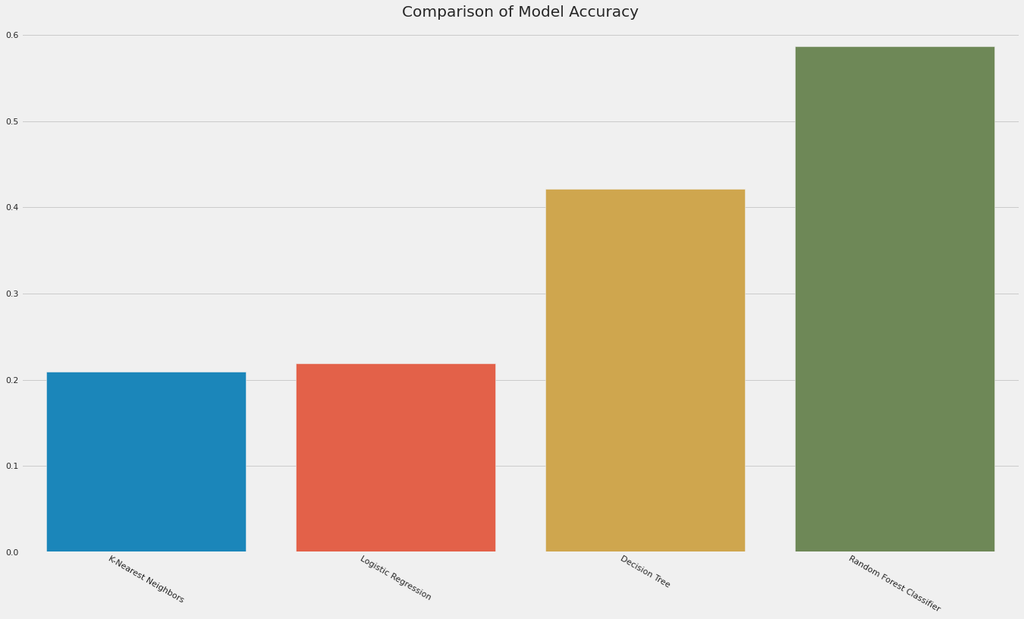

```python
#plotting the accuracies of each of the models against each other
models = ['K-Nearest Neighbors', 'Logistic Regression', 'Decision Tree', 'Random Forest Classifier']
accuracies = [knn_model_acc, log_model_acc, dec_tree_acc, rand_for_acc]
sns.barplot(x=models, y=accuracies).set(title='Comparison of Model Accuracy')
plt.xticks(rotation=-30)
```

## Prediction with New Genres

The next approach we took was training our models using the dataset that grouped sub-genres together to create new genres of their larger encompassing genres. The steps taken in this approach are exactly the same as the steps taken in the previous approach with the only exception being changing our training data and test data split. While we maintained the ratio of the split (60% training data – 40% test data), we had to change the contents of our target data as our new target variable is the ‘New Genres’ column and not the ‘Top Genres’ column.

After making these changes, we evaluated each model based on their accuracy score. The results showed a similar trend as the results in the last approach but we were able to experience a significant rise in the accuracy of each model.

Due to the change in the dataset, it can be inferred that the improvement in the accuracy scores of each model was a result of getting rid of some of the outliers in the dataset. This was especially evident in the Logistic Regression model as Logistic Regression models tend to perform better when the number of classes to classify are as small as possible.

Although this is an encouraging achievement, it still does not help us handle the issue of class imbalances as there are still genres that appear in the dataset less than 5 times and it can even be argued that grouping some of the sub genres together has led to greater class imbalances as pertains to the weights of the classes. To handle this issue, the next step we chose was to use some tools provided by scikitlearn and imbalanced-learn to adjust the weights of the classes. But before we did that, we first chose to perform a sort of sanity check.

```python
# creating the train/test split for grouped genres
y1 = df_copy1['New Genres']
X1 = df_copy1.drop(['Index', 'Title', 'Top Genre', 'Length (Duration)', 'New Genres'], axis=1)
X_train1, X_test1, y_train1, y_test1 = train_test_split(X1, y1, train_size = 0.6, random_state = 42)
```

```python
# creating a default knn classifier model
knn_model1 = KNeighborsClassifier()
knn_model1.fit(X_train1, y_train1)

#making a prediction using the knn classifier model
knn_model_prediction1 = knn_model1.predict(X_test1)
knn_model_acc1 = accuracy_score(y_test1, knn_model_prediction1)
print('K-Nearest Neighbors Accuracy:', knn_model_acc1)
```

```
K-Nearest Neighbors Accuracy: 0.38596491228070173
```

```python
#creating a default logistic regression model
log_model1 = LogisticRegression()
log_model1.fit(X_train1, y_train1)

#making a prediction using the logistic regression model
log_model_prediction1 = log_model1.predict(X_test1)
log_model_acc1 = accuracy_score(y_test1, log_model_prediction1)
print('Logistic Regression Accuracy:', log_model_acc1)
```

```
Logistic Regression Accuracy: 0.40852130325814534
```

```python
#creating a default decision tree classifier model
dec_tree_model1 = DecisionTreeClassifier()
dec_tree_model1.fit(X_train1, y_train1)

#making a prediction using the decision tree classifier model
dec_tree_prediction1 = dec_tree_model1.predict(X_test1)
dec_tree_acc1 = accuracy_score(y_test1, dec_tree_prediction1)
print('Decision Tree Accuracy:', dec_tree_acc1)
```

```
Decision Tree Accuracy: 0.543859649122807
```

```python
#creating a default random forest classifier model
rand_for_model1 = RandomForestClassifier()
rand_for_model1.fit(X_train1, y_train1)

#making a prediction using the decision tree classifier model
rand_for_model_prediction1 = rand_for_model1.predict(X_test1)
rand_for_acc1 = accuracy_score(y_test1, rand_for_model_prediction1)
print('Random Forest Classifier Accuracy:', rand_for_acc1)
```

```
Random Forest Classifier Accuracy: 0.6428571428571429
```

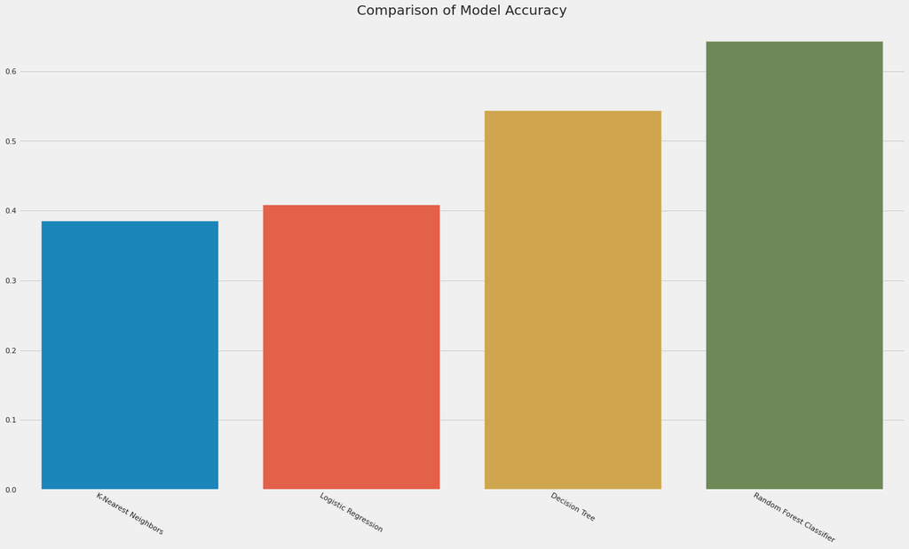

```python
#making a plot to compare the accuracies of each of the models in this step
models1 = ['K-Nearest Neighbors', 'Logistic Regression', 'Decision Tree', 'Random Forest Classifier']
accuracies1 = [knn_model_acc1, log_model_acc1, dec_tree_acc1, rand_for_acc1]
sns.barplot(x=models1, y=accuracies1).set(title='Comparison of Model Accuracy')
plt.xticks(rotation=-30)
```

## Prediction With Cross Validation

### Using Regular Genres

To ensure that our hypothesis has some truth to it, we chose to train our models using a different approach: Cross Validation. Cross Validation is a model training method that involves using random subsets of the dataset to train a model and evaluating the model’s performance on the other subsets not used in the training process. This method is used to detect and counter overfitting and could potentially counter other training issues as well.

To simplify this process, we used the cross_val_score function from sklearn which simultaneously performs cross validation on the given model and returns the model’s evaluation score. At this step of the tutorial, we chose to make the target variable the ‘Top Genre’ column. Although there are no major ideas to report at this stage, seeing as the models did not improve significantly if at all, we do see that the cross-validation procedure reflects the idea of an imbalance in our data. This is clear in the warning that states that ‘The least populated class in y has only 1 members, which is less than n_splits=10’ (currently hidden due to the filteration of the warnings in the notebook). This means that certain genres are not appropriately represented in our cross-validation splits which could ultimately affect our model’s performance and appears to do so as seen in the poor scores of each model.

```python
# creating a default knn classifier model
knn_model_cv = KNeighborsClassifier()

#making a prediction using the knn classifier model
knn_model_cv_scores = cross_val_score(knn_model_cv, X, y, cv = 10)
print('K-Nearest Neighbors Cross Validation Mean Score:', knn_model_cv_scores.mean())
```

```
K-Nearest Neighbors Cross Validation Mean Score: 0.2011608040201005
```

```python
warnings.filterwarnings('ignore')
#creating a default logistic regression model
log_model_cv = LogisticRegression()


#making a prediction using the logistic regression model
log_model_cv_scores = cross_val_score(log_model_cv, X, y, cv = 10)
print('Logistic Regression Accuracy:', log_model_cv_scores.mean())
```

```
Logistic Regression Accuracy: 0.2176532663316583
```

```python
#creating a default decision tree classifier model
dec_tree_model_cv = DecisionTreeClassifier()

#making a prediction using the decision tree classifier model
dec_tree_model_cv_scores = cross_val_score(dec_tree_model_cv, X, y, cv = 10)
print('Decision Tree Accuracy:', dec_tree_model_cv_scores.mean())
```

```
Decision Tree Accuracy: 0.43538944723618095
```

```python
#creating a default random forest classifier model
rand_for_model_cv = RandomForestClassifier()

#making a prediction using the decision tree classifier model
rand_for_model_cv_scores = cross_val_score(rand_for_model_cv, X, y, cv = 10)
print('Random Forest Classifier Accuracy:', rand_for_model_cv_scores.mean())
```

```
Random Forest Classifier Accuracy: 0.6264271356783919
```

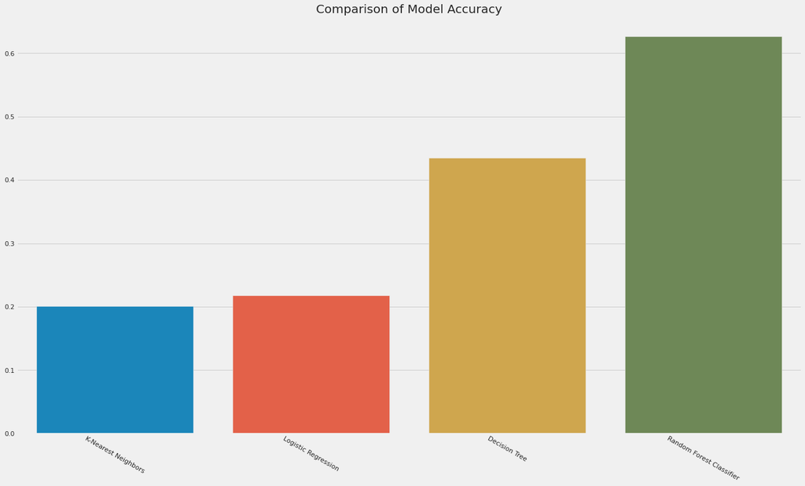

```python
models = ['K-Nearest Neighbors', 'Logistic Regression', 'Decision Tree', 'Random Forest Classifier']
accuracies = [knn_model_cv_scores.mean(), log_model_cv_scores.mean(), dec_tree_model_cv_scores.mean(), rand_for_model_cv_scores.mean()]
sns.barplot(x=models, y=accuracies).set(title='Comparison of Model Accuracy')
plt.xticks(rotation=-30)
```

### Using the New Genres Column as the Target

To try and mitigate the imbalances a bit, we chose to train the models again using cross-validation but this time with our target variable being the ‘New Genres’ column. The steps in this part are the exact same steps as the last but we can already see a change in the scores of each of the models. The constant though, is that there are still imbalances in the representation of each genre as there are genres with just 1 appearance in the dataset. This tells us that we need to address the issue of the outliers in our dataset as well as the imbalances among the more highly represented classes.

```python
# creating a default knn classifier model
knn_model_cv2 = KNeighborsClassifier()

#making a prediction using the knn classifier model
knn_model_cv_scores2 = cross_val_score(knn_model_cv2, X1, y1, cv = 10)
print('K-Nearest Neighbors Cross Validation Mean Score:', knn_model_cv_scores2.mean())
```

```
K-Nearest Neighbors Cross Validation Mean Score: 0.39262562814070345
```

```python
warnings.filterwarnings('ignore')
#creating a default logistic regression model
log_model_cv2 = LogisticRegression()


#making a prediction using the logistic regression model
log_model_cv_scores2 = cross_val_score(log_model_cv2, X1, y1, cv = 10)
print('Logistic Regression Accuracy:', log_model_cv_scores2.mean())
```

```
Logistic Regression Accuracy: 0.40722361809045227
```

```python
#creating a default decision tree classifier model
dec_tree_model_cv2 = DecisionTreeClassifier()

#making a prediction using the decision tree classifier model
dec_tree_model_cv_scores2 = cross_val_score(dec_tree_model_cv2, X1, y1, cv = 10)
print('Decision Tree Accuracy:', dec_tree_model_cv_scores2.mean())
```

```
Decision Tree Accuracy: 0.507967336683417
```

```python
#creating a default random forest classifier model
rand_for_model_cv2 = RandomForestClassifier()

#making a prediction using the decision tree classifier model
rand_for_model_cv_scores2 = cross_val_score(rand_for_model_cv2, X1, y1, cv = 10)
print('Random Forest Classifier Accuracy:', rand_for_model_cv_scores2.mean())
```

```
Random Forest Classifier Accuracy: 0.6183919597989951
```

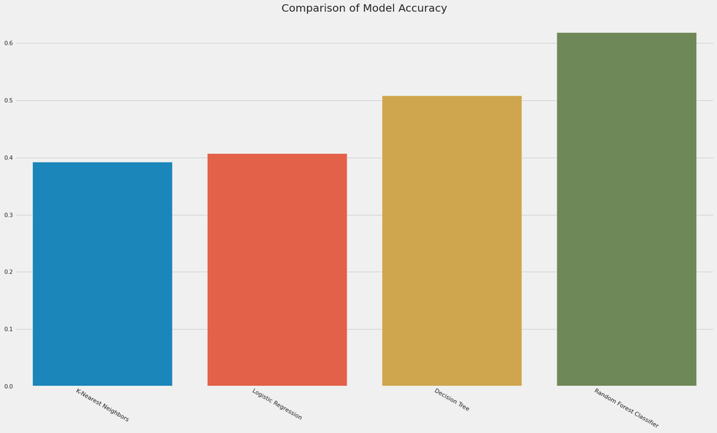

```python
models = ['K-Nearest Neighbors', 'Logistic Regression', 'Decision Tree', 'Random Forest Classifier']
accuracies = [knn_model_cv_scores2.mean(), log_model_cv_scores2.mean(), dec_tree_model_cv_scores2.mean(), rand_for_model_cv_scores2.mean()]
sns.barplot(x=models, y=accuracies).set(title='Comparison of Model Accuracy')
plt.xticks(rotation=-30)
```

# Handling Class Imbalances

## Using the Class Weight Paramater

The second approach we took to handle the class imbalances was by using the class_weight parameter that is a part of the Logistic Regression, Decision Tree Classifier, and Random Forest Classifier models. This parameter determines how to weight each class in the target variable so as to handle class imbalances in the dataset. Since our aim was to make each of the classes balanced, we chose to set the class_weight parameter to be ‘balanced’ so that each genre can be weighted similarly. The formula the weight of each genre given this setting is no_of_samples / (no_of_classes * np.bincount(y)). The purpose of this formula is to make classes with a lot samples be less weighted and to increase the weight the significantly less weighted classes. While this parameter was available to us to use for the Logistic Regression, Decision Tree Classifier, and Random Forest Classifier models, it was not available to us for the K-Nearest Neighbors model, which was disappointing to say the least but we proceeded nonetheless.

To train our models, we used the ‘Top Genre’ column as our target variable and made our predictions on that column. While we were optimistic about our decision to use the class weight parameter, things did not turn out the way we expected them to with the major disappointment being the significant drop in the accuracy of our Logistic Regression model as the model had an underwhelming accuracy score and f1 score.

While the Decision Tree and Random Forest models fared better than the Logistic Regression model, they did not have significantly good scores either. To aim to improve these scores, we chose a different route to counter imbalances, and to do that we had to use a class called SMOTE.

Side Note: The f1 score metric uses a weighted average since we are performing multiclass classification and there are some imbalances between the classes.

```python
#setting the class_weight parameter to balanced for the Logistic Regression model
log_model_weighted = LogisticRegression(class_weight='balanced')
log_model_weighted.fit(X_train, y_train)
log_model_weighted_prediction = log_model_weighted.predict(X_test)
log_model_weighted_acc = accuracy_score(y_test, log_model_weighted_prediction)
print('Logistic Regression Accuracy:', log_model_weighted_acc)
print('Logistic Regression F1 Score:', f1_score(y_test, log_model_weighted_prediction, average='weighted'))
```

```
Logistic Regression Accuracy: 0.03132832080200501
Logistic Regression F1 Score: 0.02877778828904451
```

```python
#setting the class_weight parameter to balanced for the Decision Tree Classifier
dec_model_weighted = DecisionTreeClassifier(class_weight='balanced')
dec_model_weighted.fit(X_train, y_train)
dec_model_weighted_prediction = dec_model_weighted.predict(X_test)
dec_model_weighted_acc = accuracy_score(y_test, dec_model_weighted_prediction)
print('Decison Tree Classifier Accuracy:', dec_model_weighted_acc)
print('Decision Tree Classifier F1 Score:', f1_score(y_test, dec_model_weighted_prediction, average='weighted'))
```

```
Decison Tree Classifier Accuracy: 0.4548872180451128
Decision Tree Classifier F1 Score: 0.4494902600956305
```

```python
#setting the class_weight parameter to balanced for the Random Forest Classifier
rand_model_weighted = RandomForestClassifier(class_weight='balanced')
rand_model_weighted.fit(X_train, y_train)
rand_model_weighted_prediction = rand_model_weighted.predict(X_test)
rand_model_weighted_acc = accuracy_score(y_test, rand_model_weighted_prediction)
print('Random Forest Classifier Accuracy:', rand_model_weighted_acc)
print('Random Forest Classifier F1 Score:', f1_score(y_test, rand_model_weighted_prediction, average='weighted'))
```

```
Random Forest Classifier Accuracy: 0.5538847117794486
Random Forest Classifier F1 Score: 0.5164031875637529
```

## Using SMOTE and Pipeline to handle Imbalances

SMOTE is a class provided by the imbalanced-learn module that helps to counter imbalanced classes in classification problems. To give a brief overview about what SMOTE does without going into too much detail, SMOTE balances the class distribution by randomly increasing minority class examples by replicating them. It then uses these new synthetic training records to reconstruct the dataset to have a better distribution of the classes to be classified. In addition to using SMOTE, we also used the Pipeline class which is a preprocessing tool for models and the Standard Scaler class which we used to standardize our dataset.

Now that the tools that we used have been explained it is time to explain our process. We firstly removed the major outliers in our ‘Top Genre’ column, ie genres with appearances less than 15, because although SMOTE creates synthetic examples for minority classes, significantly minor classes have such limited information that SMOTE would be unable to synthesize examples for them. After doing that, we created our training data and test data using the train_test_split function. Next, we created each model. To create the models, we used the make_pipeline function and used SMOTE, StandardScaler, and the specific model that were interested in as the parameters of the function. So the better illustrate this, to create the K-Nearest Neighbors Classifier model, we made the following function call: make_pipeline(SMOTE(random_state=42), StandardScaler(), KNeighborsClassifier()). This process was replicated for the other models and we evaluated the models using the accuracy score and the f1 score since we wanted to take into account the varying classes.

As a result of using this approach, we experienced massive improvements especially in the The K-Nearest Neighbors Classifier and the Logistic Regression model. Unfortunately, the same could not be said for the Decision Tree Classifier and the Random Forest Classifier which did not fare as expected following our approach. To mitigate this, we chose to train our models using the same dataframe without the outlier data but we opted not to use Pipeline and SMOTE in our training process. This resulted in the Decision Tree Classifier and the Random Forest Classifier experiencing major improvements to their accuracy and f1 scores.

Now that we had what we deemed to be our best models, we proceeded to tune the hyperparameters of each model.

```python
#creating the new dataframe without outliers
value_c = df_copy['Top Genre'].value_counts()
relevant_genres = value_c.index[value_c >= 15].tolist()
df_copy2 = df_copy.copy()
new_df = df_copy2[df_copy2['Top Genre'].isin(relevant_genres)]
print(new_df['Top Genre'].unique())
```

```
['adult standards' 'album rock' 'alternative dance' 'alternative metal'
 'alternative rock' 'art rock' 'blues rock' 'british invasion'
 'british soul' 'classic rock' 'classic uk pop' 'dance pop' 'dance rock'
 'disco' 'dutch cabaret' 'dutch indie' 'dutch pop' 'dutch rock' 'europop'
 'glam metal' 'glam rock' 'irish rock' 'modern rock' 'neo mellow'
 'permanent wave' 'pop']
```

```python
#making training data and test data
y_smote = new_df['Top Genre']
X_smote = new_df.drop(['Index', 'Title', 'Top Genre', 'Length (Duration)'], axis=1)
X_train_smote, X_test_smote, y_train_smote, y_test_smote = train_test_split(X_smote, y_smote, train_size = 0.75, random_state = 42)
```

```python
#making a KNN Classifier model Using Pipeline and SMOTE
knn_pipeline = make_pipeline(SMOTE(random_state=42), StandardScaler(), KNeighborsClassifier())
knn_pipeline = knn_pipeline.fit(X_train_smote, y_train_smote)
knn_pipeline_prediction = knn_pipeline.predict(X_test_smote)
knn_pipeline_accuracy = accuracy_score(y_test_smote, knn_pipeline_prediction)
knn_pipeline_f1_score = f1_score(y_test_smote, knn_pipeline_prediction, average='weighted')
print('KNN Classifier Pipeline Accuracy:', knn_pipeline_accuracy)
print('KNN Classifier Pipeline F1 Score:', knn_pipeline_f1_score)
```

```
KNN Classifier Pipeline Accuracy: 0.7244897959183674
KNN Classifier Pipeline F1 Score: 0.737981419733869
```

```python
#making a Logistic Regression model Using Pipeline and SMOTE
log_reg_pipeline = make_pipeline(SMOTE(random_state=42), StandardScaler(), LogisticRegression())
log_reg_pipeline = log_reg_pipeline.fit(X_train_smote, y_train_smote)
log_reg_pipeline_prediction = log_reg_pipeline.predict(X_test_smote)
log_reg_pipeline_accuracy = accuracy_score(y_test_smote, log_reg_pipeline_prediction)
log_reg_pipeline_f1_score = f1_score(y_test_smote, log_reg_pipeline_prediction, average='weighted')
print('Logistic Regression Pipeline Accuracy:', log_reg_pipeline_accuracy)
print('Logistic Regression Pipeline F1 Score:', log_reg_pipeline_f1_score)
```

```
Logistic Regression Pipeline Accuracy: 0.875
Logistic Regression Pipeline F1 Score: 0.8826320654859766
```

```python
#making a Decision Tree Classifier using Pipeline and SMOTE
dec_tree_pipeline = make_pipeline(SMOTE(random_state=42), StandardScaler(), DecisionTreeClassifier())
dec_tree_pipeline = dec_tree_pipeline.fit(X_train_smote, y_train_smote)
dec_tree_pipeline_pred = dec_tree_pipeline.predict(X_test_smote)
dec_tree_pipeline_accuracy = accuracy_score(y_test_smote, dec_tree_pipeline_pred)
dec_tree_pipeline_f1_score = f1_score(y_test_smote, dec_tree_pipeline_pred, average='weighted')
print('Decision Tree Pipeline Accuracy:', dec_tree_pipeline_accuracy)
print('Decision Tree Pipeline F1 Score:', dec_tree_pipeline_f1_score)
```

```
Decision Tree Pipeline Accuracy: 0.336734693877551
Decision Tree Pipeline F1 Score: 0.3450647033591895
```

```python
#training the decision tree without using smote but still using the data without outliers
dec_tree2 = DecisionTreeClassifier()
dec_tree2.fit(X_train_smote, y_train_smote)
dec_tree2_pred = dec_tree2.predict(X_test_smote)
dec_tree2_acc = accuracy_score(y_test_smote, dec_tree2_pred)
dec_tree2_f1_score = f1_score(y_test_smote, dec_tree2_pred, average='weighted')
print('Decision Tree With no Outliers Accuracy:', dec_tree2_acc)
print('Decision Tree With no Outliers F1 Score:', dec_tree2_f1_score)
```

```
Decision Tree With no Outliers Accuracy: 0.5918367346938775
Decision Tree With no Outliers F1 Score: 0.5845604610748412
```

```python
#making a Random Forest Classifier using Pipeline and SMOTE
rand_for_pipeline = make_pipeline(SMOTE(random_state=42), StandardScaler(), RandomForestClassifier())
rand_for_pipeline = rand_for_pipeline.fit(X_train_smote, y_train_smote)
rand_for_pipeline_pred = rand_for_pipeline.predict(X_test_smote)
rand_for_pipeline_accuracy = accuracy_score(y_test_smote, rand_for_pipeline_pred)
rand_for_pipeline_f1_score = f1_score(y_test_smote, rand_for_pipeline_pred, average='weighted')
print('Random Forest Pipeline Accuracy:', rand_for_pipeline_accuracy)
print('Random Forest Pipeline F1 Score:', rand_for_pipeline_f1_score)
```

```
Random Forest Pipeline Accuracy: 0.6556122448979592
Random Forest Pipeline F1 Score: 0.6648800280284004
```

```python
#making a Random Forest Classifier on the data without outliers and without using pipeline and SMOTE
rand_for2 = RandomForestClassifier()
rand_for2.fit(X_train_smote, y_train_smote)
rand_for2_pred = rand_for2.predict(X_test_smote)
rand_for2_accuracy = accuracy_score(y_test_smote, rand_for2_pred)
rand_for2_f1_score = f1_score(y_test_smote, rand_for2_pred, average='weighted')
print('Random Forest Pipeline Accuracy:', rand_for2_accuracy)
print('Random Forest Pipeline F1 Score:', rand_for2_f1_score)
```

```
Random Forest Pipeline Accuracy: 0.7474489795918368
Random Forest Pipeline F1 Score: 0.7281863314384738
```

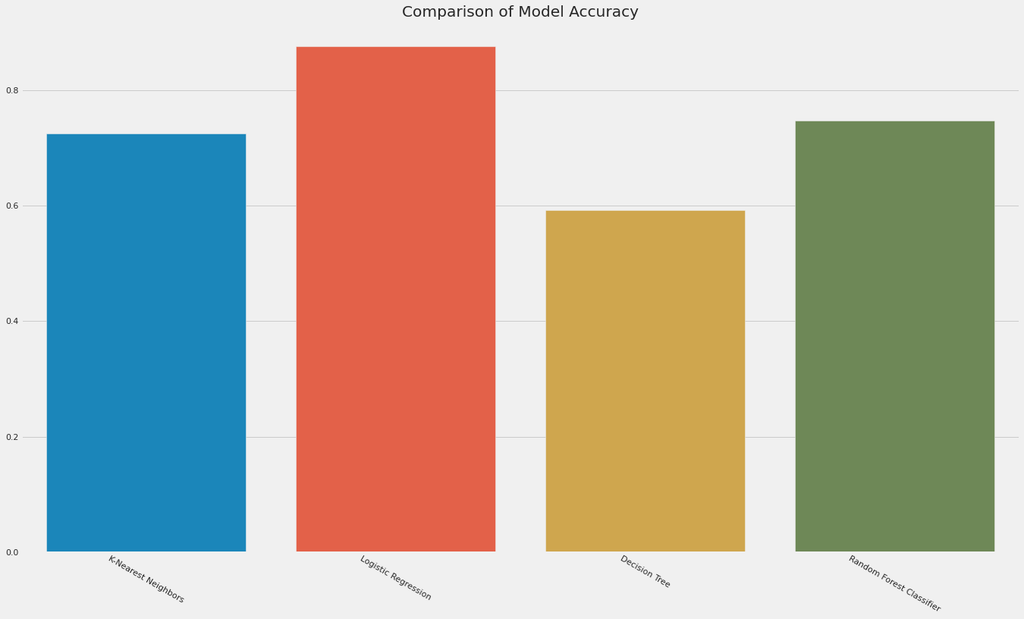

```python
#plotting the models accuracies
models1 = ['K-Nearest Neighbors', 'Logistic Regression', 'Decision Tree', 'Random Forest Classifier']
accuracies1 = [knn_pipeline_accuracy, log_reg_pipeline_accuracy, dec_tree2_acc, rand_for2_accuracy]
sns.barplot(x=models1, y=accuracies1).set(title='Comparison of Model Accuracy')
plt.xticks(rotation=-30)
```

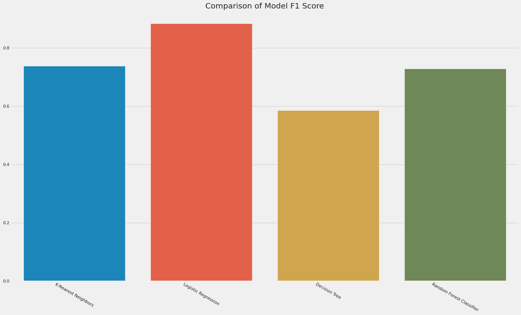

```python
#plotting the models f1 scores
models1 = ['K-Nearest Neighbors', 'Logistic Regression', 'Decision Tree', 'Random Forest Classifier']
accuracies1 = [knn_pipeline_f1_score, log_reg_pipeline_f1_score, dec_tree2_f1_score, rand_for2_f1_score]
sns.barplot(x=models1, y=accuracies1).set(title='Comparison of Model F1 Score')
plt.xticks(rotation=-30)
```

# Hyperparameter Tuning for Each Model

To tune the hyperparameters for each model, we chose to use different approaches for the different models. For the K-Nearest Neighbors Classifier and the Logistic Regression model, we had to manually adjust the hyperparameters ourselves since we created the models using the make_pipeline function whereas for the Decision Tree Classifier and the Random Forest Classifier, we used GridSearchCV since we opted to use the models that were not trained using the make_pipeline function.

For the K-Nearest Neighbors Classifier and the Logistic Regression model, the hyperparameters that we chose to adjust were the n-neighbors parameter and C parameter respectively. We chose these parameters because we did not want to overcomplicate the process and because we wanted to limit the number of computational resources expended to train the models. Once we came up with a list of the values to evaluate the models on, we used a for loop to test the impact of using each value and chose the best value based on the f1 score metric.

For the Decision Tree Classifier and the Random Forest Classifier, we chose to use GridSearchCV to tune their hyperparameters. For the Decision Tree, we chose to tune the splitter, max_depth, and criterion parameters and for the Random Forest Classifier, we chose to tune the n_estimators, max_depth, and criterion parameters.

Following the tuning process, we found our best models to be the K-Nearest Neighbors Classifier, the Logistic Regression model , and the Random Forest Classifier.

While these were good scores for each of the models, we first had to ensure that the models are genuinely producing these results before we could conclude on our accuracy and to do that, we opted to use hypothesis testing.

## 1. K-Nearest Neighbors Classifier

```python
#current evalutation metrics for best default KNN Classifier Model
print(classification_report(y_test_smote, knn_pipeline_prediction))
```

```
                   precision    recall  f1-score   support

  adult standards       0.61      0.74      0.67        27
       album rock       1.00      0.73      0.84       106
alternative dance       0.20      1.00      0.33         1
alternative metal       0.68      0.75      0.71        20
 alternative rock       0.61      0.58      0.59        19
         art rock       0.12      0.17      0.14         6
       blues rock       0.50      0.33      0.40         6
 british invasion       1.00      1.00      1.00        11
     british soul       0.67      1.00      0.80         6
     classic rock       0.37      0.88      0.52         8
   classic uk pop       0.33      1.00      0.50         3
        dance pop       0.83      0.60      0.70        25
       dance rock       0.67      0.43      0.52        14
            disco       0.33      0.75      0.46         4
    dutch cabaret       0.74      0.78      0.76        18
      dutch indie       0.76      0.79      0.78        24
        dutch pop       0.74      0.61      0.67        23
       dutch rock       0.33      0.33      0.33         6
          europop       1.00      0.67      0.80         6
       glam metal       0.83      1.00      0.91         5
        glam rock       0.83      1.00      0.91         5
       irish rock       0.80      1.00      0.89         8
      modern rock       0.83      0.91      0.87        11
       neo mellow       0.14      0.50      0.22         2
   permanent wave       0.87      1.00      0.93        13
              pop       0.92      0.73      0.81        15

         accuracy                           0.72       392
        macro avg       0.64      0.74      0.66       392
     weighted avg       0.78      0.72      0.74       392
```

```python
#list of possible values for n-neighbors
k_range = list(range(10, 310, 10))
k_range.insert(0, 5)

#variables to keep track of the features of the best knn model
knn_best_model = knn_pipeline
knn_best_prediction = knn_pipeline_prediction
knn_best_acc = accuracy_score(y_test_smote, knn_best_prediction)
knn_best_f1_score = f1_score(y_test_smote, knn_best_prediction, average='weighted')
k_value = 0

#creating a model with each value of k
for neighbor in k_range:
  current_model = make_pipeline(SMOTE(random_state=42), StandardScaler(), KNeighborsClassifier(n_neighbors=neighbor))
  current_model = current_model.fit(X_train_smote, y_train_smote)
  current_model_prediction = current_model.predict(X_test_smote)
  current_model_acc = accuracy_score(y_test_smote, current_model_prediction)
  current_model_f1_score = f1_score(y_test_smote, current_model_prediction, average='weighted')

  if current_model_f1_score >= knn_best_f1_score:
    knn_best_model = current_model
    knn_best_prediction = current_model_prediction
    knn_best_acc = current_model_acc
    knn_best_f1_score = current_model_f1_score
    k_value = neighbor

#outputting the features of the best model
print('KNN Best Model Accuracy:', knn_best_acc)
print('KNN Best Model F1 Score:', knn_best_f1_score)
print('K Value:', k_value)
print(classification_report(y_test_smote, knn_best_prediction))
```

```
KNN Best Model Accuracy: 0.7244897959183674
KNN Best Model F1 Score: 0.737981419733869
K Value: 5
                   precision    recall  f1-score   support

  adult standards       0.61      0.74      0.67        27
       album rock       1.00      0.73      0.84       106
alternative dance       0.20      1.00      0.33         1
alternative metal       0.68      0.75      0.71        20
 alternative rock       0.61      0.58      0.59        19
         art rock       0.12      0.17      0.14         6
       blues rock       0.50      0.33      0.40         6
 british invasion       1.00      1.00      1.00        11
     british soul       0.67      1.00      0.80         6
     classic rock       0.37      0.88      0.52         8
   classic uk pop       0.33      1.00      0.50         3
        dance pop       0.83      0.60      0.70        25
       dance rock       0.67      0.43      0.52        14
            disco       0.33      0.75      0.46         4
    dutch cabaret       0.74      0.78      0.76        18
      dutch indie       0.76      0.79      0.78        24
        dutch pop       0.74      0.61      0.67        23
       dutch rock       0.33      0.33      0.33         6
          europop       1.00      0.67      0.80         6
       glam metal       0.83      1.00      0.91         5
        glam rock       0.83      1.00      0.91         5
       irish rock       0.80      1.00      0.89         8
      modern rock       0.83      0.91      0.87        11
       neo mellow       0.14      0.50      0.22         2
   permanent wave       0.87      1.00      0.93        13
              pop       0.92      0.73      0.81        15

         accuracy                           0.72       392
        macro avg       0.64      0.74      0.66       392
     weighted avg       0.78      0.72      0.74       392
```

## 2. Logistic Regression

```python
#current evaluation metrics for the best Logistic Regression model
print(classification_report(y_test_smote, log_reg_pipeline_prediction))
```

```
                   precision    recall  f1-score   support

  adult standards       0.89      0.93      0.91        27
       album rock       1.00      0.90      0.95       106
alternative dance       0.50      1.00      0.67         1
alternative metal       1.00      0.85      0.92        20
 alternative rock       1.00      0.84      0.91        19
         art rock       0.33      0.33      0.33         6
       blues rock       1.00      0.67      0.80         6
 british invasion       1.00      1.00      1.00        11
     british soul       0.86      1.00      0.92         6
     classic rock       0.60      0.75      0.67         8
   classic uk pop       0.40      0.67      0.50         3
        dance pop       0.95      0.80      0.87        25
       dance rock       0.87      0.93      0.90        14
            disco       0.36      1.00      0.53         4
    dutch cabaret       0.89      0.89      0.89        18
      dutch indie       0.83      1.00      0.91        24
        dutch pop       0.86      0.78      0.82        23
       dutch rock       0.43      0.50      0.46         6
          europop       1.00      0.67      0.80         6
       glam metal       0.56      1.00      0.71         5
        glam rock       0.83      1.00      0.91         5
       irish rock       1.00      1.00      1.00         8
      modern rock       1.00      1.00      1.00        11
       neo mellow       0.40      1.00      0.57         2
   permanent wave       0.93      1.00      0.96        13
              pop       1.00      0.80      0.89        15

         accuracy                           0.88       392
        macro avg       0.79      0.86      0.80       392
     weighted avg       0.91      0.88      0.88       392
```

```python
#choosing the best logistic regression model based on the C values
c_values = [1, 10, 100, 1000, 1e4, 1e5, 1e6, 1e7]

#variables to keep track of features of the best logistic regression model
log_reg_best_model = log_reg_pipeline
log_reg_best_prediction = log_reg_pipeline_prediction
log_reg_best_acc = accuracy_score(y_test_smote, log_reg_best_prediction)
log_reg_best_f1_score = f1_score(y_test_smote, log_reg_best_prediction, average='weighted')
c_value = 1

#creating a model with each value of k
for c in c_values:
  current_model = make_pipeline(SMOTE(random_state=42), StandardScaler(), LogisticRegression(C=c))
  current_model = current_model.fit(X_train_smote, y_train_smote)
  current_model_prediction = current_model.predict(X_test_smote)
  current_model_acc = accuracy_score(y_test_smote, current_model_prediction)
  current_model_f1_score = f1_score(y_test_smote, current_model_prediction, average='weighted')

  if current_model_f1_score >= log_reg_best_f1_score:
    log_reg_best_model = current_model
    log_reg_best_prediction = current_model_prediction
    log_reg_best_acc = current_model_acc
    log_reg_best_f1_score = current_model_f1_score
    c_value = c

#outputting the features of the best model
print('Logistic Regression Best Model Accuracy:', log_reg_best_acc)
print('Logistic Regression Best Model F1 Score:', log_reg_best_f1_score)
print('C Value:', k_value)
print(classification_report(y_test_smote, log_reg_best_prediction))
```

```
Logistic Regression Best Model Accuracy: 0.8801020408163265
Logistic Regression Best Model F1 Score: 0.8868128888835565
C Value: 5
                   precision    recall  f1-score   support

  adult standards       0.89      0.93      0.91        27
       album rock       1.00      0.90      0.95       106
alternative dance       0.50      1.00      0.67         1
alternative metal       1.00      0.85      0.92        20
 alternative rock       1.00      0.84      0.91        19
         art rock       0.33      0.33      0.33         6
       blues rock       1.00      0.67      0.80         6
 british invasion       1.00      1.00      1.00        11
     british soul       0.86      1.00      0.92         6
     classic rock       0.58      0.88      0.70         8
   classic uk pop       0.40      0.67      0.50         3
        dance pop       0.95      0.80      0.87        25
       dance rock       0.87      0.93      0.90        14
            disco       0.40      1.00      0.57         4
    dutch cabaret       0.89      0.94      0.92        18
      dutch indie       0.83      1.00      0.91        24
        dutch pop       0.90      0.78      0.84        23
       dutch rock       0.50      0.50      0.50         6
          europop       1.00      0.67      0.80         6
       glam metal       0.56      1.00      0.71         5
        glam rock       0.83      1.00      0.91         5
       irish rock       0.89      1.00      0.94         8
      modern rock       1.00      1.00      1.00        11
       neo mellow       0.40      1.00      0.57         2
   permanent wave       1.00      1.00      1.00        13
              pop       1.00      0.80      0.89        15

         accuracy                           0.88       392
        macro avg       0.79      0.86      0.81       392
     weighted avg       0.91      0.88      0.89       392
```

## 3. Decision Tree Classifier

```python
#current evaluation metrics for the best Decision Tree  model
print(classification_report(y_test_smote, dec_tree2_pred))
```

```
                   precision    recall  f1-score   support

  adult standards       0.31      0.33      0.32        27
       album rock       0.64      0.75      0.69       106
alternative dance       0.25      1.00      0.40         1
alternative metal       0.56      0.50      0.53        20
 alternative rock       0.38      0.32      0.34        19
         art rock       0.14      0.17      0.15         6
       blues rock       0.00      0.00      0.00         6
 british invasion       1.00      1.00      1.00        11
     british soul       0.45      0.83      0.59         6
     classic rock       0.71      0.62      0.67         8
   classic uk pop       0.25      0.33      0.29         3
        dance pop       0.43      0.40      0.42        25
       dance rock       0.67      0.43      0.52        14
            disco       0.50      0.25      0.33         4
    dutch cabaret       0.71      0.56      0.63        18
      dutch indie       0.70      0.67      0.68        24
        dutch pop       0.44      0.48      0.46        23
       dutch rock       0.33      0.17      0.22         6
          europop       0.80      0.67      0.73         6
       glam metal       1.00      0.80      0.89         5
        glam rock       0.71      1.00      0.83         5
       irish rock       0.70      0.88      0.78         8
      modern rock       0.89      0.73      0.80        11
       neo mellow       0.50      0.50      0.50         2
   permanent wave       1.00      0.92      0.96        13
              pop       0.62      0.53      0.57        15

         accuracy                           0.59       392
        macro avg       0.57      0.57      0.55       392
     weighted avg       0.59      0.59      0.58       392
```

```python
# 72 models
search_space ={
    "splitter" : ["best"],
    "max_depth" : [40, 80, 120, 160, 200, 240, 280, 320, 360, 400, None],
    "criterion" : ["gini", "log_loss"]
}
GS = GridSearchCV(estimator= dec_tree2,
                  param_grid= search_space,
                  scoring= "f1_weighted",
                  refit = "f1_weighted",
                  cv = 5,
                  verbose = 4
                  )
```

```python
GS.fit(X_train_smote, y_train_smote)
dec_tree_best_model = GS.best_estimator_
```

```
Fitting 5 folds for each of 22 candidates, totalling 110 fits
[CV 1/5] END criterion=gini, max_depth=40, splitter=best;, score=0.495 total time=   0.1s
[CV 2/5] END criterion=gini, max_depth=40, splitter=best;, score=0.477 total time=   0.0s
[CV 3/5] END criterion=gini, max_depth=40, splitter=best;, score=0.523 total time=   0.1s
[CV 4/5] END criterion=gini, max_depth=40, splitter=best;, score=0.490 total time=   0.1s
[CV 5/5] END criterion=gini, max_depth=40, splitter=best;, score=0.469 total time=   0.1s
[CV 1/5] END criterion=gini, max_depth=80, splitter=best;, score=0.475 total time=   0.0s
[CV 2/5] END criterion=gini, max_depth=80, splitter=best;, score=0.462 total time=   0.0s
[CV 3/5] END criterion=gini, max_depth=80, splitter=best;, score=0.524 total time=   0.1s
[CV 4/5] END criterion=gini, max_depth=80, splitter=best;, score=0.497 total time=   0.1s
[CV 5/5] END criterion=gini, max_depth=80, splitter=best;, score=0.484 total time=   0.1s
[CV 1/5] END criterion=gini, max_depth=120, splitter=best;, score=0.488 total time=   0.0s
[CV 2/5] END criterion=gini, max_depth=120, splitter=best;, score=0.481 total time=   0.0s
[CV 3/5] END criterion=gini, max_depth=120, splitter=best;, score=0.527 total time=   0.0s
[CV 4/5] END criterion=gini, max_depth=120, splitter=best;, score=0.515 total time=   0.1s
[CV 5/5] END criterion=gini, max_depth=120, splitter=best;, score=0.476 total time=   0.0s
[CV 1/5] END criterion=gini, max_depth=160, splitter=best;, score=0.500 total time=   0.0s
[CV 2/5] END criterion=gini, max_depth=160, splitter=best;, score=0.467 total time=   0.1s
[CV 3/5] END criterion=gini, max_depth=160, splitter=best;, score=0.517 total time=   0.1s
[CV 4/5] END criterion=gini, max_depth=160, splitter=best;, score=0.511 total time=   0.0s
[CV 5/5] END criterion=gini, max_depth=160, splitter=best;, score=0.501 total time=   0.1s
[CV 1/5] END criterion=gini, max_depth=200, splitter=best;, score=0.483 total time=   0.1s
[CV 2/5] END criterion=gini, max_depth=200, splitter=best;, score=0.472 total time=   0.1s
[CV 3/5] END criterion=gini, max_depth=200, splitter=best;, score=0.503 total time=   0.0s
[CV 4/5] END criterion=gini, max_depth=200, splitter=best;, score=0.504 total time=   0.0s
[CV 5/5] END criterion=gini, max_depth=200, splitter=best;, score=0.491 total time=   0.0s
[CV 1/5] END criterion=gini, max_depth=240, splitter=best;, score=0.515 total time=   0.1s
[CV 2/5] END criterion=gini, max_depth=240, splitter=best;, score=0.476 total time=   0.1s
[CV 3/5] END criterion=gini, max_depth=240, splitter=best;, score=0.537 total time=   0.0s
[CV 4/5] END criterion=gini, max_depth=240, splitter=best;, score=0.477 total time=   0.1s
[CV 5/5] END criterion=gini, max_depth=240, splitter=best;, score=0.487 total time=   0.0s
[CV 1/5] END criterion=gini, max_depth=280, splitter=best;, score=0.496 total time=   0.0s
[CV 2/5] END criterion=gini, max_depth=280, splitter=best;, score=0.458 total time=   0.0s
[CV 3/5] END criterion=gini, max_depth=280, splitter=best;, score=0.513 total time=   0.0s
[CV 4/5] END criterion=gini, max_depth=280, splitter=best;, score=0.503 total time=   0.0s
[CV 5/5] END criterion=gini, max_depth=280, splitter=best;, score=0.498 total time=   0.1s
[CV 1/5] END criterion=gini, max_depth=320, splitter=best;, score=0.499 total time=   0.1s
[CV 2/5] END criterion=gini, max_depth=320, splitter=best;, score=0.459 total time=   0.0s
[CV 3/5] END criterion=gini, max_depth=320, splitter=best;, score=0.542 total time=   0.0s
[CV 4/5] END criterion=gini, max_depth=320, splitter=best;, score=0.485 total time=   0.1s
```

[output cut: 56 more lines]

```
[CV 1/5] END criterion=log_loss, max_depth=360, splitter=best;, score=nan total time=   0.0s
[CV 2/5] END criterion=log_loss, max_depth=360, splitter=best;, score=nan total time=   0.0s
[CV 3/5] END criterion=log_loss, max_depth=360, splitter=best;, score=nan total time=   0.0s
[CV 4/5] END criterion=log_loss, max_depth=360, splitter=best;, score=nan total time=   0.0s
[CV 5/5] END criterion=log_loss, max_depth=360, splitter=best;, score=nan total time=   0.0s
[CV 1/5] END criterion=log_loss, max_depth=400, splitter=best;, score=nan total time=   0.0s
[CV 2/5] END criterion=log_loss, max_depth=400, splitter=best;, score=nan total time=   0.0s
[CV 3/5] END criterion=log_loss, max_depth=400, splitter=best;, score=nan total time=   0.0s
[CV 4/5] END criterion=log_loss, max_depth=400, splitter=best;, score=nan total time=   0.0s
[CV 5/5] END criterion=log_loss, max_depth=400, splitter=best;, score=nan total time=   0.0s
[CV 1/5] END criterion=log_loss, max_depth=None, splitter=best;, score=nan total time=   0.0s
[CV 2/5] END criterion=log_loss, max_depth=None, splitter=best;, score=nan total time=   0.0s
[CV 3/5] END criterion=log_loss, max_depth=None, splitter=best;, score=nan total time=   0.0s
[CV 4/5] END criterion=log_loss, max_depth=None, splitter=best;, score=nan total time=   0.0s
[CV 5/5] END criterion=log_loss, max_depth=None, splitter=best;, score=nan total time=   0.0s
```

```python
dec_tree_pred = dec_tree_best_model.predict(X_test_smote)
dec_tree_accuracy = accuracy_score(y_test_smote, dec_tree_pred)
dec_tree_f1_score = f1_score(y_test_smote, dec_tree_pred, average='weighted')
print('Best Decision Tree Classifier Accuracy:', dec_tree_accuracy)
print('Best Decision Tree Classifier F1 Score:',dec_tree_f1_score)
```

```
Best Decision Tree Classifier Accuracy: 0.5816326530612245
Best Decision Tree Classifier F1 Score: 0.5736032458966369
```

## 4. Random Forest Classifier

```python
#current evaluation metrics for the best Random Forest model
print(classification_report(y_test_smote, rand_for2_pred))
```

```
                   precision    recall  f1-score   support

  adult standards       0.74      0.63      0.68        27
       album rock       0.63      0.94      0.75       106
alternative dance       0.50      1.00      0.67         1
alternative metal       0.70      0.80      0.74        20
 alternative rock       0.80      0.63      0.71        19
         art rock       0.00      0.00      0.00         6
       blues rock       0.00      0.00      0.00         6
 british invasion       1.00      1.00      1.00        11
     british soul       1.00      1.00      1.00         6
     classic rock       1.00      0.62      0.77         8
   classic uk pop       1.00      0.33      0.50         3
        dance pop       0.61      0.56      0.58        25
       dance rock       1.00      0.36      0.53        14
            disco       1.00      0.25      0.40         4
    dutch cabaret       1.00      0.67      0.80        18
      dutch indie       0.73      0.79      0.76        24
        dutch pop       0.71      0.65      0.68        23
       dutch rock       1.00      0.17      0.29         6
          europop       1.00      0.67      0.80         6
       glam metal       1.00      1.00      1.00         5
        glam rock       1.00      1.00      1.00         5
       irish rock       1.00      1.00      1.00         8
      modern rock       1.00      0.82      0.90        11
       neo mellow       1.00      0.50      0.67         2
   permanent wave       0.93      1.00      0.96        13
              pop       1.00      0.80      0.89        15

         accuracy                           0.75       392
        macro avg       0.82      0.66      0.70       392
     weighted avg       0.76      0.75      0.73       392
```

```python
# 66 models
search_space ={
    "n_estimators" : [100, 200, 500],
    "max_depth" : [40, 80, 120, 160, 200, 240, 280, 320, 360, 400, None],
    "criterion" : ["gini", "entropy"]
}
GS = GridSearchCV(estimator= rand_for2,
                  param_grid= search_space,
                  scoring= "f1_weighted",
                  refit = "f1_weighted",
                  cv = 5,
                  verbose = 4
                  )
```

```python
GS.fit(X_train_smote, y_train_smote)
```

```
Fitting 5 folds for each of 66 candidates, totalling 330 fits
[CV 1/5] END criterion=gini, max_depth=40, n_estimators=100;, score=0.598 total time=   0.4s
[CV 2/5] END criterion=gini, max_depth=40, n_estimators=100;, score=0.662 total time=   0.5s
[CV 3/5] END criterion=gini, max_depth=40, n_estimators=100;, score=0.663 total time=   0.5s
[CV 4/5] END criterion=gini, max_depth=40, n_estimators=100;, score=0.669 total time=   0.5s
[CV 5/5] END criterion=gini, max_depth=40, n_estimators=100;, score=0.641 total time=   0.4s
[CV 1/5] END criterion=gini, max_depth=40, n_estimators=200;, score=0.629 total time=   0.8s
[CV 2/5] END criterion=gini, max_depth=40, n_estimators=200;, score=0.663 total time=   0.9s
[CV 3/5] END criterion=gini, max_depth=40, n_estimators=200;, score=0.666 total time=   0.8s
[CV 4/5] END criterion=gini, max_depth=40, n_estimators=200;, score=0.683 total time=   0.8s
[CV 5/5] END criterion=gini, max_depth=40, n_estimators=200;, score=0.625 total time=   0.8s
[CV 1/5] END criterion=gini, max_depth=40, n_estimators=500;, score=0.613 total time=   2.1s
[CV 2/5] END criterion=gini, max_depth=40, n_estimators=500;, score=0.663 total time=   2.1s
[CV 3/5] END criterion=gini, max_depth=40, n_estimators=500;, score=0.658 total time=   2.1s
[CV 4/5] END criterion=gini, max_depth=40, n_estimators=500;, score=0.690 total time=   2.0s
[CV 5/5] END criterion=gini, max_depth=40, n_estimators=500;, score=0.634 total time=   2.0s
[CV 1/5] END criterion=gini, max_depth=80, n_estimators=100;, score=0.635 total time=   0.5s
[CV 2/5] END criterion=gini, max_depth=80, n_estimators=100;, score=0.694 total time=   0.5s
[CV 3/5] END criterion=gini, max_depth=80, n_estimators=100;, score=0.649 total time=   0.5s
[CV 4/5] END criterion=gini, max_depth=80, n_estimators=100;, score=0.685 total time=   0.5s
[CV 5/5] END criterion=gini, max_depth=80, n_estimators=100;, score=0.653 total time=   0.5s
[CV 1/5] END criterion=gini, max_depth=80, n_estimators=200;, score=0.630 total time=   0.9s
[CV 2/5] END criterion=gini, max_depth=80, n_estimators=200;, score=0.664 total time=   0.9s
[CV 3/5] END criterion=gini, max_depth=80, n_estimators=200;, score=0.663 total time=   0.9s
[CV 4/5] END criterion=gini, max_depth=80, n_estimators=200;, score=0.684 total time=   0.9s
[CV 5/5] END criterion=gini, max_depth=80, n_estimators=200;, score=0.646 total time=   0.9s
[CV 1/5] END criterion=gini, max_depth=80, n_estimators=500;, score=0.640 total time=   2.7s
[CV 2/5] END criterion=gini, max_depth=80, n_estimators=500;, score=0.665 total time=   2.6s
[CV 3/5] END criterion=gini, max_depth=80, n_estimators=500;, score=0.689 total time=   2.2s
[CV 4/5] END criterion=gini, max_depth=80, n_estimators=500;, score=0.692 total time=   2.2s
[CV 5/5] END criterion=gini, max_depth=80, n_estimators=500;, score=0.659 total time=   2.2s
[CV 1/5] END criterion=gini, max_depth=120, n_estimators=100;, score=0.643 total time=   0.5s
[CV 2/5] END criterion=gini, max_depth=120, n_estimators=100;, score=0.668 total time=   0.5s
[CV 3/5] END criterion=gini, max_depth=120, n_estimators=100;, score=0.661 total time=   0.5s
[CV 4/5] END criterion=gini, max_depth=120, n_estimators=100;, score=0.685 total time=   0.5s
[CV 5/5] END criterion=gini, max_depth=120, n_estimators=100;, score=0.628 total time=   0.6s
[CV 1/5] END criterion=gini, max_depth=120, n_estimators=200;, score=0.653 total time=   0.9s
[CV 2/5] END criterion=gini, max_depth=120, n_estimators=200;, score=0.668 total time=   0.9s
[CV 3/5] END criterion=gini, max_depth=120, n_estimators=200;, score=0.661 total time=   0.9s
[CV 4/5] END criterion=gini, max_depth=120, n_estimators=200;, score=0.704 total time=   0.9s
```

[output cut: 276 more lines]

```
[CV 1/5] END criterion=entropy, max_depth=None, n_estimators=100;, score=0.546 total time=   0.6s
[CV 2/5] END criterion=entropy, max_depth=None, n_estimators=100;, score=0.575 total time=   0.6s
[CV 3/5] END criterion=entropy, max_depth=None, n_estimators=100;, score=0.579 total time=   0.6s
[CV 4/5] END criterion=entropy, max_depth=None, n_estimators=100;, score=0.603 total time=   0.6s
[CV 5/5] END criterion=entropy, max_depth=None, n_estimators=100;, score=0.519 total time=   0.6s
[CV 1/5] END criterion=entropy, max_depth=None, n_estimators=200;, score=0.550 total time=   1.2s
[CV 2/5] END criterion=entropy, max_depth=None, n_estimators=200;, score=0.603 total time=   1.2s
[CV 3/5] END criterion=entropy, max_depth=None, n_estimators=200;, score=0.560 total time=   1.3s
[CV 4/5] END criterion=entropy, max_depth=None, n_estimators=200;, score=0.590 total time=   1.2s
[CV 5/5] END criterion=entropy, max_depth=None, n_estimators=200;, score=0.519 total time=   1.2s
[CV 1/5] END criterion=entropy, max_depth=None, n_estimators=500;, score=0.541 total time=   3.0s
[CV 2/5] END criterion=entropy, max_depth=None, n_estimators=500;, score=0.622 total time=   3.0s
[CV 3/5] END criterion=entropy, max_depth=None, n_estimators=500;, score=0.591 total time=   3.0s
[CV 4/5] END criterion=entropy, max_depth=None, n_estimators=500;, score=0.599 total time=   3.0s
[CV 5/5] END criterion=entropy, max_depth=None, n_estimators=500;, score=0.535 total time=   3.0s
```

```
GridSearchCV(cv=5, estimator=RandomForestClassifier(),
             param_grid={'criterion': ['gini', 'entropy'],
                         'max_depth': [40, 80, 120, 160, 200, 240, 280, 320,
                                       360, 400, None],
                         'n_estimators': [100, 200, 500]},
             refit='f1_weighted', scoring='f1_weighted', verbose=4)
```

```python
rand_for_best_model = GS.best_estimator_
rand_for_pred = rand_for_best_model.predict(X_test_smote)
rand_for_accuracy = accuracy_score(y_test_smote, rand_for_pred)
rand_for_f1_score = f1_score(y_test_smote, rand_for_pred, average='weighted')
print('Best Random Forest Classifier Accuracy:', rand_for_accuracy)
print('Best Random Forest Classifier F1 Score:', rand_for_f1_score)
```

```
Best Random Forest Classifier Accuracy: 0.7474489795918368
Best Random Forest Classifier F1 Score: 0.729317899868886
```

# Hypothesis Testing

## 1. K-Nearest Neighbors

```python
conf_matrix = confusion_matrix(y_test_smote, knn_best_prediction)
stat, p, dof, expected = chi2_contingency(conf_matrix)
print('Chi-square statistic=',stat)
print('P Value=',p)
alpha=0.01
if p < alpha:
    print('Model is not a random guesser')
else:
    print('Model is a random guesser')
```

```
Chi-square statistic= 4988.16504697308
P Value= 0.0
Model is not a random guesser
```

## 2. Logistic Regression

```python
conf_matrix = confusion_matrix(y_test_smote, log_reg_best_prediction)
stat, p, dof, expected = chi2_contingency(conf_matrix)
print('Chi-square statistic=',stat)
print('P Value=',p)
alpha=0.01
if p < alpha:
    print('Model is not a random guesser')
else:
    print('Model is a random guesser')
```

```
Chi-square statistic= 6858.623010695137
P Value= 0.0
Model is not a random guesser
```

## 3. Random Forest Classifier

```python
conf_matrix = pd.crosstab(y_test_smote, rand_for_pred)
stat, p, dof, expected = chi2_contingency(conf_matrix)
print('Chi-square statistic=',stat)
print('P Value=',p)
alpha=0.01
if p < alpha:
    print('Model is not a random guesser')
else:
    print('Model is a random guesser')
```

```
Chi-square statistic= 6048.980406626208
P Value= 0.0
Model is not a random guesser
```

## Plot of Final Model Accuracies and F1 Scores

```
[Text(0.5, 1.0, 'Comparison of Model Accuracy')]
```

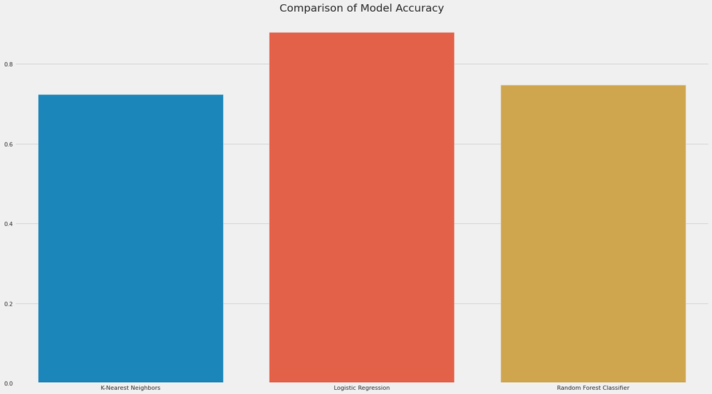

```python
models = ['K-Nearest Neighbors', 'Logistic Regression', 'Random Forest Classifier']
accuracies = [knn_best_acc, log_reg_best_acc, rand_for_accuracy]
sns.barplot(x=models, y=accuracies).set(title='Comparison of Model Accuracy')
```

```
[Text(0.5, 1.0, 'Comparison of Model F1 Score')]
```

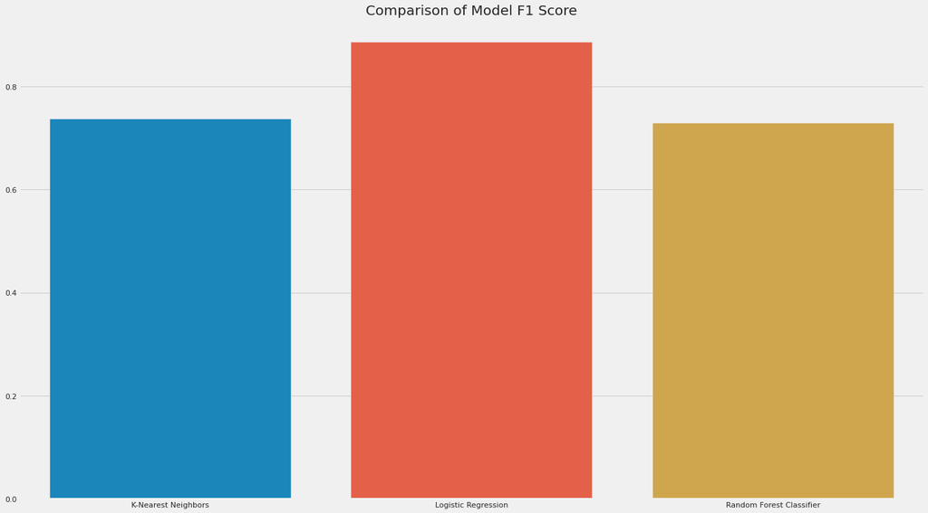

```python
models = ['K-Nearest Neighbors', 'Logistic Regression', 'Random Forest Classifier']
accuracies = [knn_best_f1_score, log_reg_best_f1_score, rand_for_f1_score]
sns.barplot(x=models, y=accuracies).set(title='Comparison of Model F1 Score')
```

# Conclusion and Future Considerations

In this tutorial we presented our approach to solving a multiclass classification problem by attempting to predict the genre of a song based on various features of the song. While this initially started off as a straightforward problem, we eventually had to deal with the imbalances between each genre in the dataset. To handle this issue, we settled on removing outliers from the dataset and using the SMOTE class to balance out each genre in the dataset.

While we have positive results from our findings, we think there are still methods we would have to utilize in the future to improve our models' accuracies such as creating more features for each genre or using only specific features for each genre, but this has definitely been a good start.